# Tree-Based Methods

Module 12

Ray J. Hoobler

## Libraries

```r
library(tidyverse)
library(ISLR2)
# install.packages("tree")
library(tree)
```

# Basics of Decision Trees – Regression

## Hitters Data Set from ISLR2

```r
hitters <- na.omit(Hitters) |> as_tibble()
hitters
```

| AtBat | Hits | HmRun | Runs | RBI | Walks | Years | CAtBat | CHits | CHmRun | CRuns | CRBI | CWalks | League | Division | PutOuts | Assists | Errors | Salary | NewLeague |
| --- | --- | --- | --- | --- | --- | --- | --- | --- | --- | --- | --- | --- | --- | --- | --- | --- | --- | --- | --- |
| 315 | 81 | 7 | 24 | 38 | 39 | 14 | 3449 | 835 | 69 | 321 | 414 | 375 | N | W | 632 | 43 | 10 | 475.000 | N |
| 479 | 130 | 18 | 66 | 72 | 76 | 3 | 1624 | 457 | 63 | 224 | 266 | 263 | A | W | 880 | 82 | 14 | 480.000 | A |
| 496 | 141 | 20 | 65 | 78 | 37 | 11 | 5628 | 1575 | 225 | 828 | 838 | 354 | N | E | 200 | 11 | 3 | 500.000 | N |
| 321 | 87 | 10 | 39 | 42 | 30 | 2 | 396 | 101 | 12 | 48 | 46 | 33 | N | E | 805 | 40 | 4 | 91.500 | N |
| 594 | 169 | 4 | 74 | 51 | 35 | 11 | 4408 | 1133 | 19 | 501 | 336 | 194 | A | W | 282 | 421 | 25 | 750.000 | A |
| 185 | 37 | 1 | 23 | 8 | 21 | 2 | 214 | 42 | 1 | 30 | 9 | 24 | N | E | 76 | 127 | 7 | 70.000 | A |
| 298 | 73 | 0 | 24 | 24 | 7 | 3 | 509 | 108 | 0 | 41 | 37 | 12 | A | W | 121 | 283 | 9 | 100.000 | A |
| 323 | 81 | 6 | 26 | 32 | 8 | 2 | 341 | 86 | 6 | 32 | 34 | 8 | N | W | 143 | 290 | 19 | 75.000 | N |
| 401 | 92 | 17 | 49 | 66 | 65 | 13 | 5206 | 1332 | 253 | 784 | 890 | 866 | A | E | 0 | 0 | 0 | 1100.000 | A |
| 574 | 159 | 21 | 107 | 75 | 59 | 10 | 4631 | 1300 | 90 | 702 | 504 | 488 | A | E | 238 | 445 | 22 | 517.143 | A |

[output cut: 253 more lines]

## Regression Using the Hitters

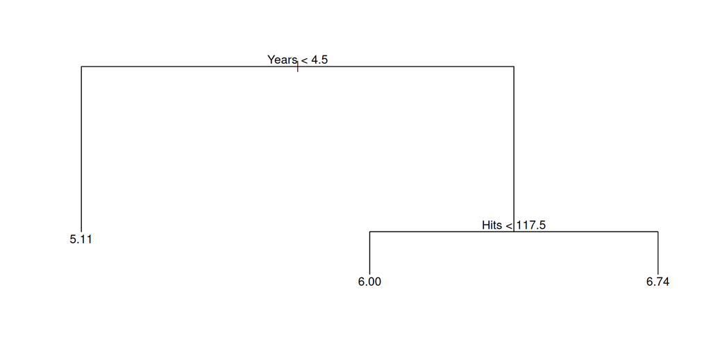

```r
# fit the data to a simple regression model based on the number of years played and the number of hits from the previous year
# restrict the number of splits to 3 by setting the mincut parameter to 50

hitters_tree_8_1 <- tree(log(Salary) ~ Years + Hits, data = hitters, mincut = 50)
plot(hitters_tree_8_1)
text(hitters_tree_8_1, digits = 3)
```

## Plot of Data with Decision Tree Values

### The red segments are based on splits from the decision tree

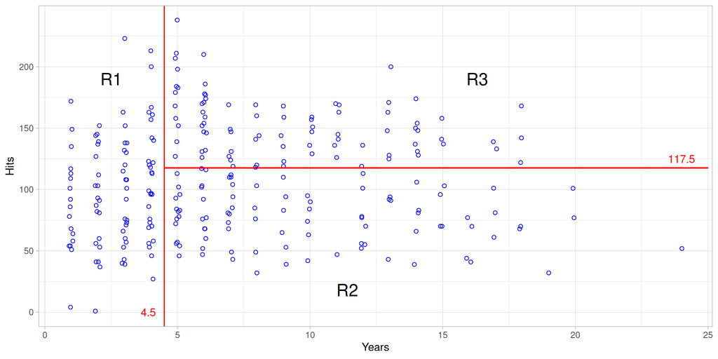

```r
hitters |>
  ggplot() +
  geom_point(aes(x = Years, y = Hits), color = "blue", position = position_jitter(width = 0.1, height = 0.1), shape = 21) +
  geom_segment(x = 4.5, xend = 25, y = 117.5, color = "red") +
  geom_vline(xintercept = 4.5, color = "red") +
  annotate("text", x = 24, y = 125, label = "117.5", color = "red") +
  annotate("text", x = 3.9, y = 0, label = "4.5", color = "red") +
  annotate("text", x = 2.5, y = 190, label = "R1", color = "black", size = 6) +
  annotate("text", x = 11.4, y = 18, label = "R2", color = "black", size = 6) +
  annotate("text", x = 16.3, y = 190, label = "R3", color = "black", size = 6) +
  theme_light()
```

### Generating Splits?

Goal is to find regions $R_1, \ldots, R_J$ that minimize the residual sum of squares (RSS) within each region.

$$\sum_{j=1}^{J} \sum_{i \in R_j} (y_i - \hat{y}_{R_j})^2$$

## Regression Tree Analysis for the Hitters Data (ISLR2 Figure 8.4)

Nine (unnamed features) were included in the model from figure 8.4; however, I couldn’t reproduce the same results, so I used 10 features that were not based on cumulative statistics.

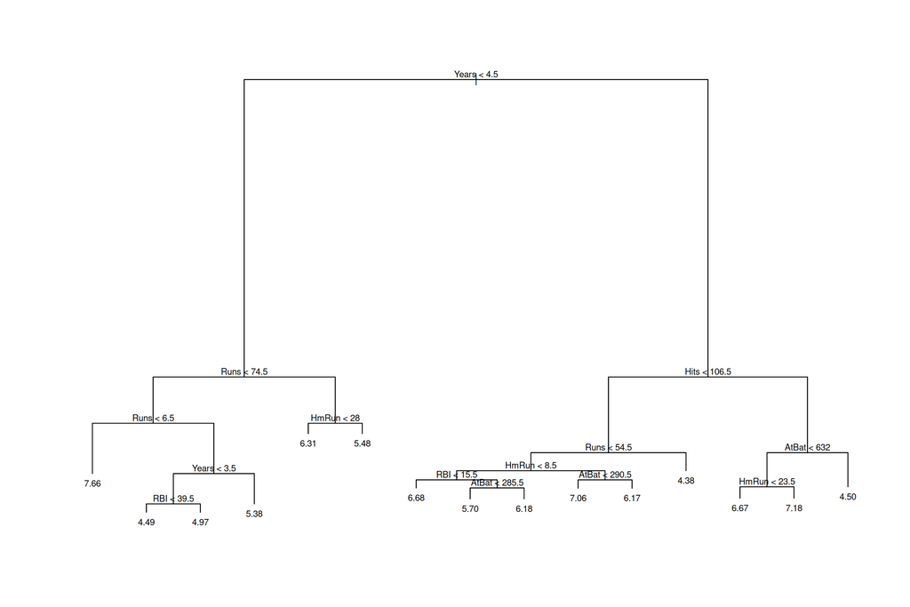

```r
set.seed(1)

train <- sample(1:nrow(hitters), nrow(hitters)/2 + 1)
# hitters[train, ]
# hitters[-train,]

# AtBat + Hits + HmRun + Runs + RBI + Walks + Years + PutOuts + Assists + Errors

hitters_tree_8_4 <- tree(
  formula = log(Salary) ~ AtBat + Hits + HmRun + Runs + RBI + Walks + Years + PutOuts + Assists + Errors,
  data = hitters,
  control = tree.control(nobs = length(train), minsize = 2, mindev = 0.01),
  subset = train)

# par(pin = c(6, 4))  # Sets physical dimensions in inches (width, height)
plot(hitters_tree_8_4)
text(hitters_tree_8_4, pretty = 0, digits = 3, cex = 0.7, adj = c(0.5, 0.8))
```

## Regression Tree Analysis for the Hitters Dataset (ISLR2 Figure 8.5)

```r
set.seed(1)
cv_hitters_tree_8_4 <- cv.tree(hitters_tree_8_4, FUN = prune.tree, K = 10)
plot(cv_hitters_tree_8_4$size, cv_hitters_tree_8_4$dev, type = "b")
```

```r
cv_hitters_tree_8_4
```

```
$size
 [1] 15 14 13 10  9  8  7  6  5  3  2  1

$dev
 [1]  59.06288  58.79853  58.79853  56.57428  56.46547  56.55295  60.15679
 [8]  61.31232  61.31232  63.74406  74.28324 108.79830

$k
 [1]      -Inf  1.231152  1.235242  1.380117  1.525860  1.668804  2.652881
 [8]  4.457421  5.020619  7.099941 11.126931 43.728005

$method
[1] "deviance"

attr(,"class")
[1] "prune"         "tree.sequence"
```

[figure not shown]

## Pruning the Tree

### Cost complexity pruning

$$\sum_{m=1}^{|T|} \sum_{i: \,i \in R_m} (y_i - \hat{y}_{R_m})^2 + \alpha |T|$$

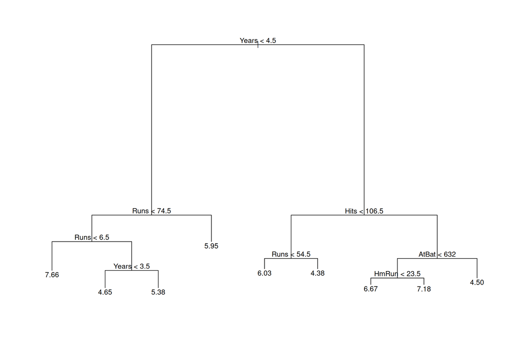

```r
prune_cv_hitters_tree_8_4 <- prune.tree(hitters_tree_8_4, best = 9)
plot(prune_cv_hitters_tree_8_4)
text(prune_cv_hitters_tree_8_4, pretty = 0, digits = 3)
```

## Summary of the Pruned Tree

```r
summary(prune_cv_hitters_tree_8_4)
```

```
Regression tree:
snip.tree(tree = hitters_tree_8_4, nodes = c(18L, 12L, 5L))
Variables actually used in tree construction:
[1] "Years" "Runs"  "Hits"  "AtBat" "HmRun"
Number of terminal nodes:  9
Residual mean deviance:  0.1634 = 20.1 / 123
Distribution of residuals:
     Min.   1st Qu.    Median      Mean   3rd Qu.      Max.
-1.046000 -0.249100 -0.001706  0.000000  0.236500  1.161000
```

## Prediction From Tree-Based Regression

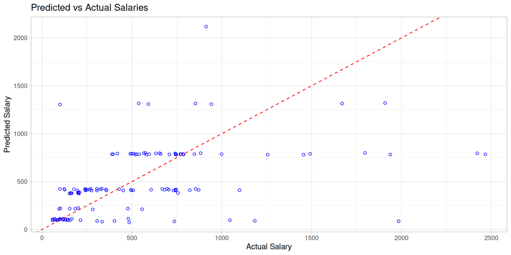

```r
salary_pred <- predict(prune_cv_hitters_tree_8_4, newdata = hitters[-train,])

tibble(
  salary_pred = salary_pred,
  actual_salary = hitters[-train,]$Salary
) |>
  ggplot() +
  geom_point(aes(x = actual_salary, y = exp(salary_pred)), color = "blue", position = position_jitter(width = 10, height = 10), shape = 21) +
  geom_abline(color = "red", linetype = "dashed") +
  labs(
    x = "Actual Salary",
    y = "Predicted Salary",
    title = "Predicted vs Actual Salaries"
  ) +
  theme_light()
```

# Basics of Decision Trees – Classification

## Classification Crieteria

For regression, we used RSS as the criterion for splitting. This is not an option for classification.

Options:

**Classification Error Rate**: The fraction of training observations in a region that do not belong to the most common class.

$$E = 1 - \max_k \hat{p}_{mk}$$

$\hat{p}_{mk}$ is the proportion of observations in the $m$th region from the $k$th class.

**Gini Index**: A measure of total variance across the $K$ classes.

$$G = \sum_{k=1}^{K} \hat{p}_{mk} (1 - \hat{p}_{mk})$$

The Gini index is small if all the $\hat{p}_{mk}$ are close to 0 or 1; indicating a node with mostly one class.

**Entropy**: A measure of disorder in a region.

$$D = -\sum_{k=1}^{K} \hat{p}_{mk} \log \hat{p}_{mk}$$

Entropy will be near zero if the $\hat{p}_{mk}$ are all near zero or one; again, indicating a node with mostly one class.

## Classification Using the Hart Data

[UCI Machine Learning Repository: Heart Disease](https://doi.org/10.24432/C52P4X)

Attribute Information: – Only 14 used – 1. #3 (age)  
– 2. #4 (sex)  
– 3. #9 (cp)  
– 4. #10 (trestbps)  
– 5. #12 (chol)  
– 6. #16 (fbs)  
– 7. #19 (restecg)  
– 8. #32 (thalach)  
– 9. #38 (exang)  
– 10. #40 (oldpeak)  
– 11. #41 (slope)  
– 12. #44 (ca)  
– 13. #51 (thal)  
– 14. #58 (num) (the predicted attribute)

## Classification Using the Hart Data (cont.)

3 age: age in years 4 sex: sex (1 = male; 0 = female)

9 cp: chest pain type – Value 1: typical angina – Value 2: atypical angina – Value 3: non-anginal pain – Value 4: asymptomatic 10 trestbps: resting blood pressure (in mm Hg on admission to the hospital)

12 chol: serum cholestoral in mg/dl

16 fbs: (fasting blood sugar > 120 mg/dl) (1 = true; 0 = false)

19 restecg: resting electrocardiographic results  
– Value 0: normal  
– Value 1: having ST-T wave abnormality (T wave inversions and/or ST elevation or depression of > 0.05 mV)  
– Value 2: showing probable or definite left ventricular hypertrophy by Estes’ criteria

32 thalach: maximum heart rate achieved

38 exang: exercise induced angina (1 = yes; 0 = no)

40 oldpeak = ST depression induced by exercise relative to rest 41 slope: the slope of the peak exercise ST segment

44 ca: number of major vessels (0-3) colored by flourosopy

51 thal: 3 = normal; 6 = fixed defect; 7 = reversable defect

58 num: diagnosis of heart disease (angiographic disease status)

- Value 0: < 50% diameter narrowing
- Value 1: > 50% diameter narrowing

(in any major vessel: attributes 59 through 68 are vessels)

## Classification Using the Hart Data (cont.)

### Inspect the data

```r
# Using the abreviations above the column names are
heart_col_names <- c("age", "sex", "cp", "trestbps", "chol", "fbs", "restecg", "thalach", "exang", "oldpeak", "slope", "ca", "thal", "num")

heart <- read_csv("datasets/heart+disease/processed.cleveland.data", col_names = heart_col_names, na = "?")
heart
```

| age | sex | cp | trestbps | chol | fbs | restecg | thalach | exang | oldpeak | slope | ca | thal | num |
| --- | --- | --- | --- | --- | --- | --- | --- | --- | --- | --- | --- | --- | --- |
| 63 | 1 | 1 | 145 | 233 | 1 | 2 | 150 | 0 | 2.3 | 3 | 0 | 6 | 0 |
| 67 | 1 | 4 | 160 | 286 | 0 | 2 | 108 | 1 | 1.5 | 2 | 3 | 3 | 2 |
| 67 | 1 | 4 | 120 | 229 | 0 | 2 | 129 | 1 | 2.6 | 2 | 2 | 7 | 1 |
| 37 | 1 | 3 | 130 | 250 | 0 | 0 | 187 | 0 | 3.5 | 3 | 0 | 3 | 0 |
| 41 | 0 | 2 | 130 | 204 | 0 | 2 | 172 | 0 | 1.4 | 1 | 0 | 3 | 0 |
| 56 | 1 | 2 | 120 | 236 | 0 | 0 | 178 | 0 | 0.8 | 1 | 0 | 3 | 0 |
| 62 | 0 | 4 | 140 | 268 | 0 | 2 | 160 | 0 | 3.6 | 3 | 2 | 3 | 3 |
| 57 | 0 | 4 | 120 | 354 | 0 | 0 | 163 | 1 | 0.6 | 1 | 0 | 3 | 0 |
| 63 | 1 | 4 | 130 | 254 | 0 | 2 | 147 | 0 | 1.4 | 2 | 1 | 7 | 2 |
| 53 | 1 | 4 | 140 | 203 | 1 | 2 | 155 | 1 | 3.1 | 3 | 0 | 7 | 1 |

[output cut: 293 more lines]

```r
heart |> count(num)
```

| num | n |
| --- | --- |
| 0 | 164 |
| 1 | 55 |
| 2 | 36 |
| 3 | 35 |
| 4 | 13 |

## Classification Using the Hart Data (cont.)

> The fluoroscopic data consisted of the number of major vessels that appeared to contain calcium.

## Set `num` as a binary factor

```r
heart_clean <- heart |>
  mutate(num_binary = if_else(num == 0, 0, 1)) |>
  select(-num) |>
  mutate(
    num_binary = factor(num_binary, levels = c(0, 1), labels = c("no", "yes")),
    sex = factor(sex, levels = c(0, 1), labels = c("female", "male")),
    cp = as.factor(cp),
    fbs = as.factor(fbs),
    restecg = as.factor(restecg),
    exang = as.factor(exang),
    slope = as.factor(slope),
    ca = as.numeric(ca),
    thal = as.factor(thal)
    )

heart_clean
```

| age | sex | cp | trestbps | chol | fbs | restecg | thalach | exang | oldpeak | slope | ca | thal | num_binary |
| --- | --- | --- | --- | --- | --- | --- | --- | --- | --- | --- | --- | --- | --- |
| 63 | male | 1 | 145 | 233 | 1 | 2 | 150 | 0 | 2.3 | 3 | 0 | 6 | no |
| 67 | male | 4 | 160 | 286 | 0 | 2 | 108 | 1 | 1.5 | 2 | 3 | 3 | yes |
| 67 | male | 4 | 120 | 229 | 0 | 2 | 129 | 1 | 2.6 | 2 | 2 | 7 | yes |
| 37 | male | 3 | 130 | 250 | 0 | 0 | 187 | 0 | 3.5 | 3 | 0 | 3 | no |
| 41 | female | 2 | 130 | 204 | 0 | 2 | 172 | 0 | 1.4 | 1 | 0 | 3 | no |
| 56 | male | 2 | 120 | 236 | 0 | 0 | 178 | 0 | 0.8 | 1 | 0 | 3 | no |
| 62 | female | 4 | 140 | 268 | 0 | 2 | 160 | 0 | 3.6 | 3 | 2 | 3 | yes |
| 57 | female | 4 | 120 | 354 | 0 | 0 | 163 | 1 | 0.6 | 1 | 0 | 3 | no |
| 63 | male | 4 | 130 | 254 | 0 | 2 | 147 | 0 | 1.4 | 2 | 1 | 7 | yes |
| 53 | male | 4 | 140 | 203 | 1 | 2 | 155 | 1 | 3.1 | 3 | 0 | 7 | yes |

[output cut: 293 more lines]

## Classification Tree for the Hart Data

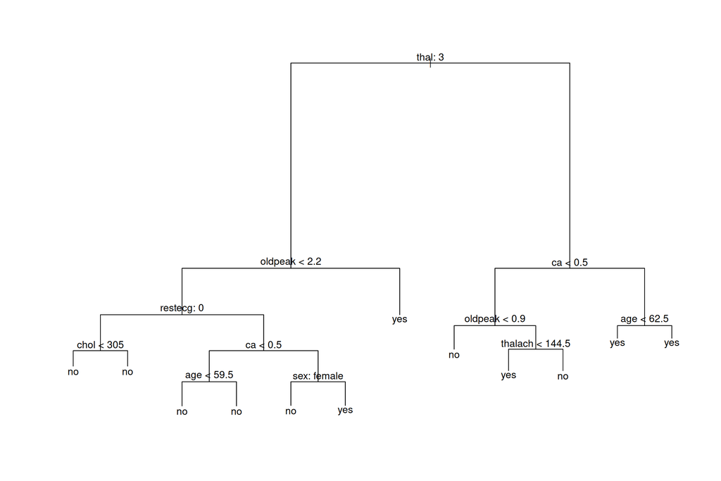

```r
set.seed(1)
train <- sample(1:nrow(heart_clean), nrow(heart_clean)/2 + 1)
# summary(heart_tree)

heart_tree <- tree(num_binary ~ ., data = heart_clean, subset = train)
plot(heart_tree)
text(heart_tree, pretty = 0, digits = 3)
```

## Cross-Validation of the Hart Data Classifiation Model

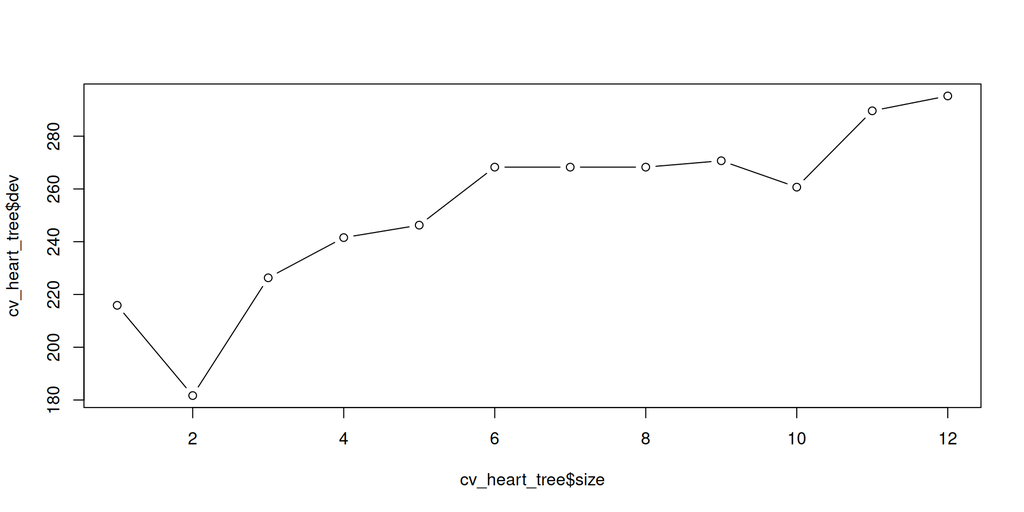

```r
set.seed(1)
cv_heart_tree <- cv.tree(heart_tree, FUN = prune.tree, K = 10)
plot(cv_heart_tree$size, cv_heart_tree$dev, type = "b")
```

### Plot of pruned tree

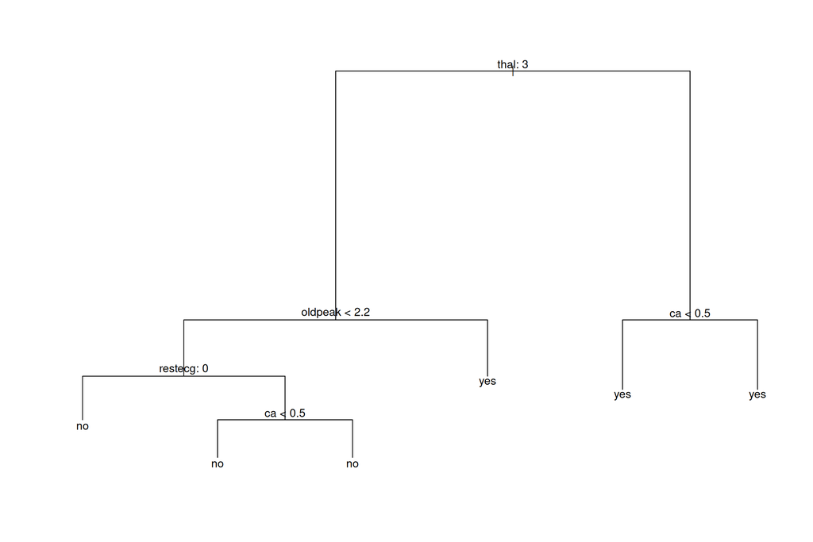

```r
prune_heart_tree <- prune.tree(heart_tree, best = 6)
plot(prune_heart_tree)
text(prune_heart_tree, pretty = 0, digits = 3)
```